## Laboratorio 3 - Bruno Mitio A. Silva

```r
library(ggplot2)
library(dplyr)
library(tidyr)
```

# geom_point

1. Quais sao os aspectos esteticos (aesthetics) exigidos (obrigatorios) da funcao geom_point()?

```r
?geom_point
```

```
## starting httpd help server ...
```

```
##  done
```

R: x e y

2. Faca um grafico de dispersao do preco (price) pela variavel quilates (carat). Utilize as funções xlab() e ylab() para trocar os labels dos eixos x e y, respectivamente.

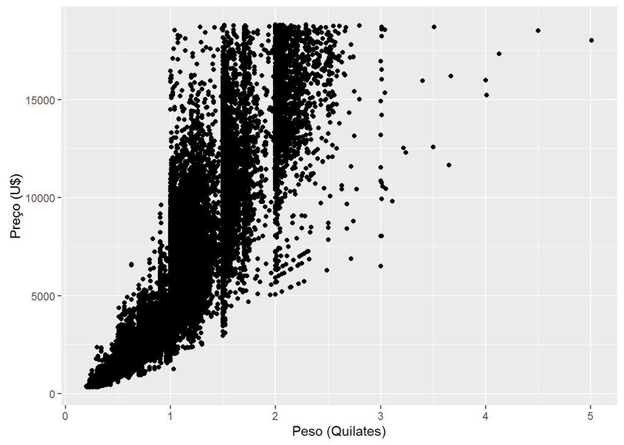

```r
ggplot(diamonds, aes(x = carat, y = price))+
  geom_point()+
  xlab("Peso (Quilates)")+
  ylab("Preço (U$)")
```

3. Utilize a facets para fazer graficos de dispersão do preco pela variavel quilate (o mesmo gráfico do exercício 1) para cada nivel da variavel claridade (clarity).

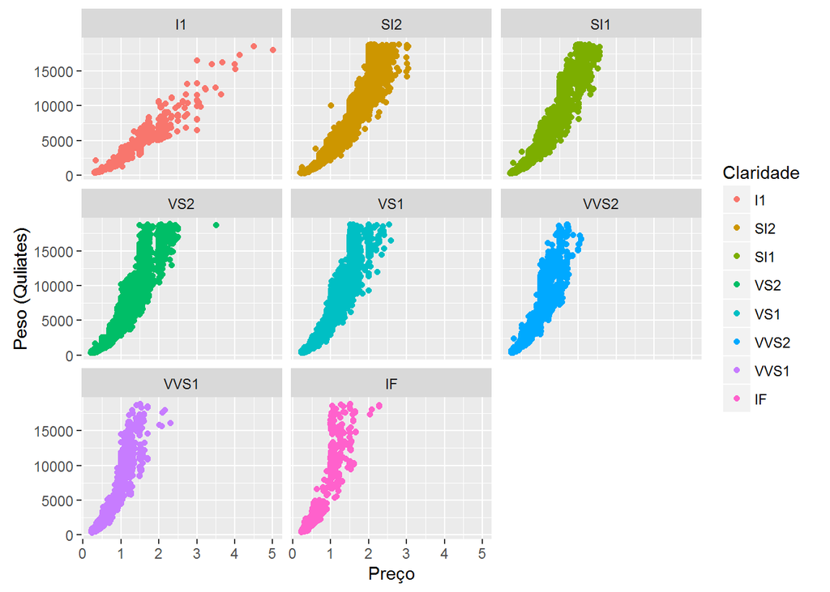

```r
ggplot(diamonds, aes(x = carat, y = price))+
  labs(x = "Preço", y = "Peso (Quliates)", colour = "Claridade")+
  geom_point(aes(colour = clarity))+
  facet_wrap(~clarity)
```

# geom_histogram

4. Quais sao os aspectos esteticos (aesthetics) exigidos (obrigatorios) da funcao geom_histogram()?

```r
?geom_histogram
?geom_bar
```

R: x

5. Faca um histograma da variavel preço. Modifique a cor das barras de forma que elas nao pareçam grudadas umas nas outras.

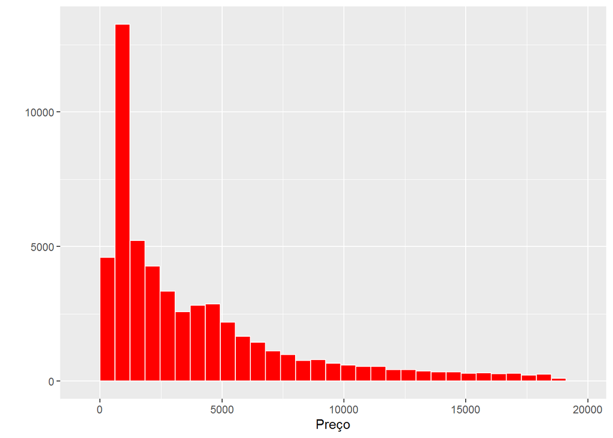

```r
ggplot(diamonds, aes(x = price))+
  labs(x = "Preço", y =" " )+
  geom_histogram(fill = "red", colour = "white")
```

6. Utilize a funcao geom_density() para adicionar ao grafico anterior uma estimativa suavizada da densidade.

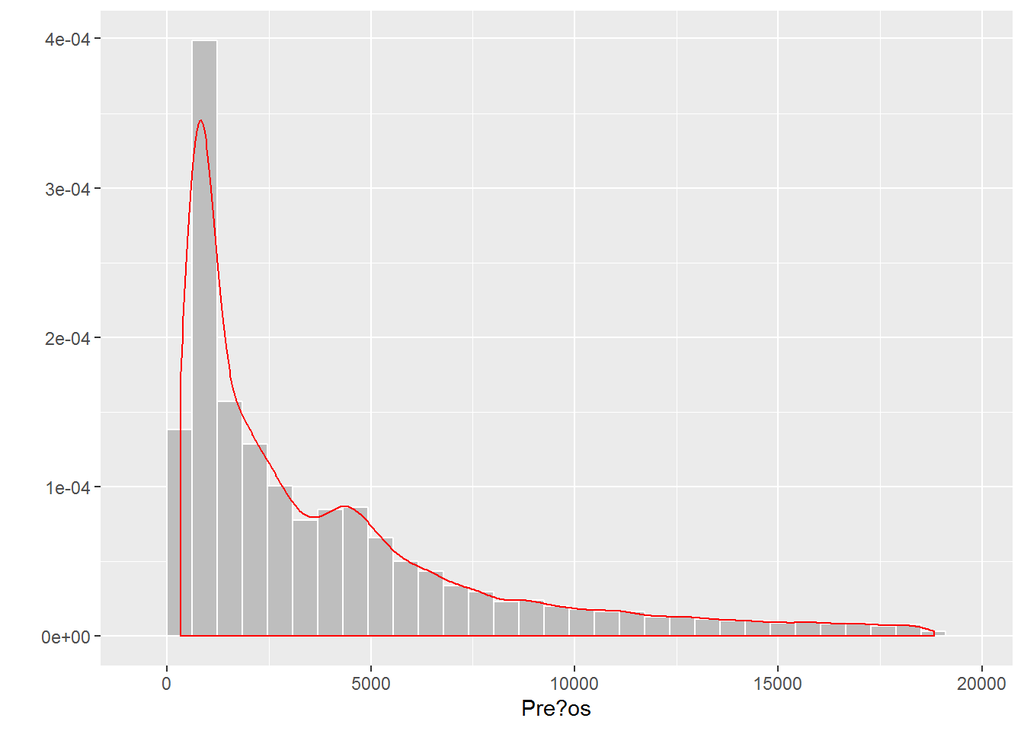

```r
ggplot(diamonds, aes(x = price))+
  labs(x = "Pre?os", y =" " )+
  geom_histogram(aes(y =..density..), fill = "gray", colour = "white")+
  geom_density(colour = "red")
```

# geom_boxplot

7. Quais sao os aspectos esteticos (aesthetics) exigidos (obrigatorios) da funcao geom_boxplot()?

```r
?geom_boxplot
```

R: lower, middle, upper, x, ymax e ymin.

8. Faca boxplots da variável preco coloridos de acordo com a variavel corte (cut).

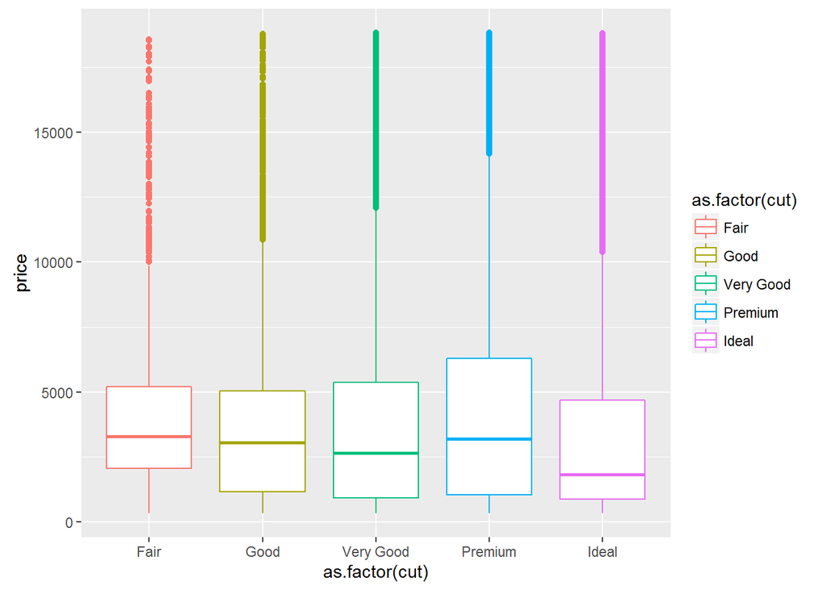

```r
ggplot(diamonds, aes(x = as.factor(cut), y = price, colour = as.factor(cut)))+
  geom_boxplot()
```

9. Substitua as cores padroes e remova a legenda do grafico anterior.

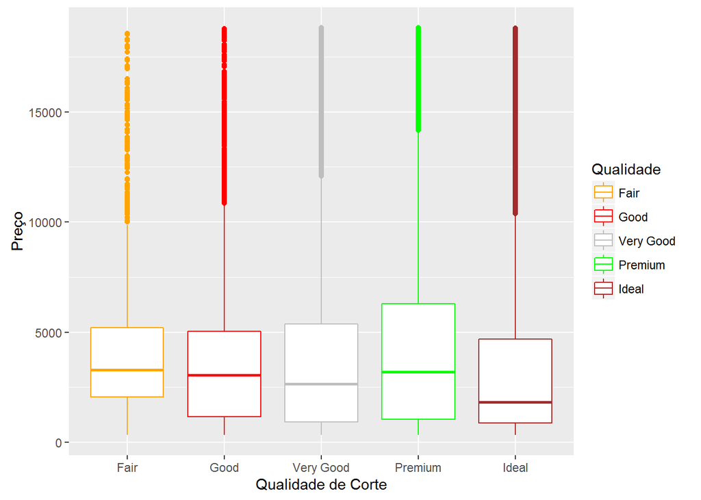

```r
ggplot(diamonds, aes(x = as.factor(cut), y = price, colour = as.factor(cut)))+
  labs(x = "Qualidade de Corte", y ="Preço", colour = "Qualidade" )+
  geom_boxplot()+
  scale_color_manual(values = c("orange", "red","gray","green","brown"))
```

# geom_bar

10. Quais são os aspectos estéticos (aesthetics) exigidos (obrigatórios) da função geom_bar()?

```r
?geom_bar
```

R: x (igual ao geom_histogram)

11. Faca um grafico de barras do numero de diamantes em cada categoria da variavel cor (color).

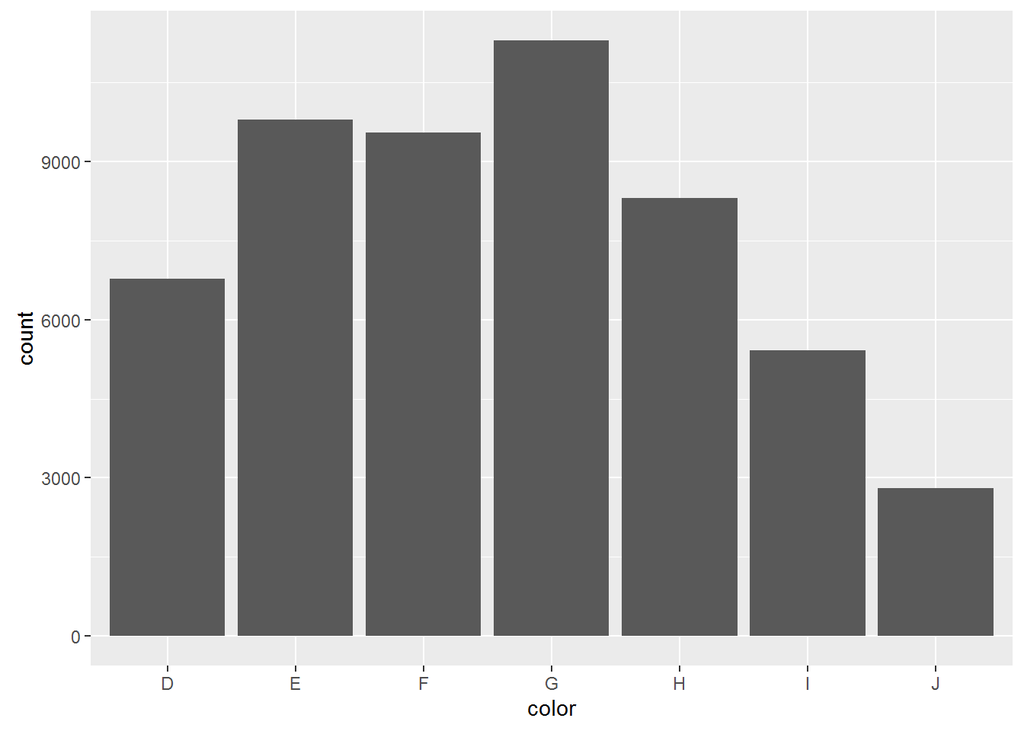

```r
ggplot(diamonds, aes(x = color))+
  geom_bar()
```

# Outra base de dados (economics)

```r
head(economics)
```

```
## Source: local data frame [6 x 6]
##
##         date   pce    pop psavert uempmed unemploy
##       (date) (dbl)  (int)   (dbl)   (dbl)    (int)
## 1 1967-07-01 507.4 198712    12.5     4.5     2944
## 2 1967-08-01 510.5 198911    12.5     4.7     2945
## 3 1967-09-01 516.3 199113    11.7     4.6     2958
## 4 1967-10-01 512.9 199311    12.5     4.9     3143
## 5 1967-11-01 518.1 199498    12.5     4.7     3066
## 6 1967-12-01 525.8 199657    12.1     4.8     3018
```

Faca um grafico de dispersao do numero de desempregados (eixo x) pelo tempo medio de desemprego (eixo y). Nao se esqueca de alterar o label dos eixos.

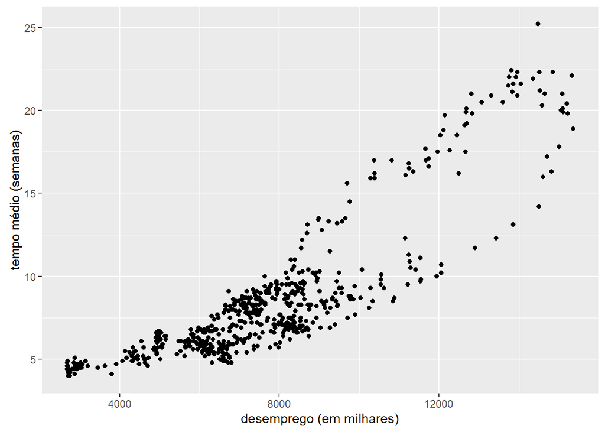

```r
economics %>%
  ggplot(aes(x =unemploy, y = uempmed))+
  geom_point()+
  xlab("desemprego (em milhares)")+
  ylab("tempo médio (semanas)")
```

Faca o mesmo grafico do exercicio anterior, no entanto, os pontos devem ter cores diferentes para cada ano, seguindo uma escala continua.

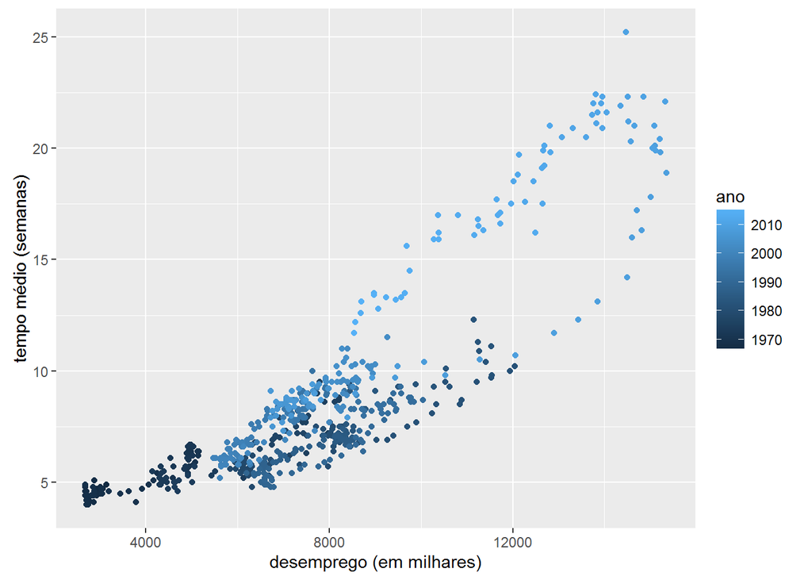

```r
eco1 <- economics %>%
  mutate(ano = substr(date, 1, 4))
eco1 %>%
  ggplot(aes(x = unemploy, y=uempmed, colour = as.numeric(ano)))+
  geom_point()+
  labs(x = "desemprego (em milhares)", y = "tempo médio (semanas)", colour = "ano")
```

Faça um gráfico de linha do número de desempregados (eixo y) e a data (eixo x).

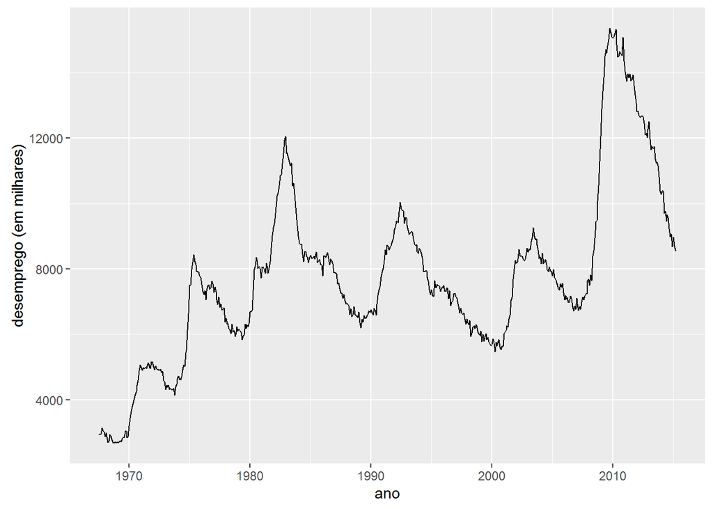

```r
economics %>%
  ggplot(aes(x = date, y = unemploy))+
  xlab("ano")+
  ylab("desemprego (em milhares)")+
  geom_line()
```

Repita o grafico anterior, no entanto desta vez a periodicidade deve ser anual e o valor apresentado no eixo y deve ser o numero medio de desempregados.

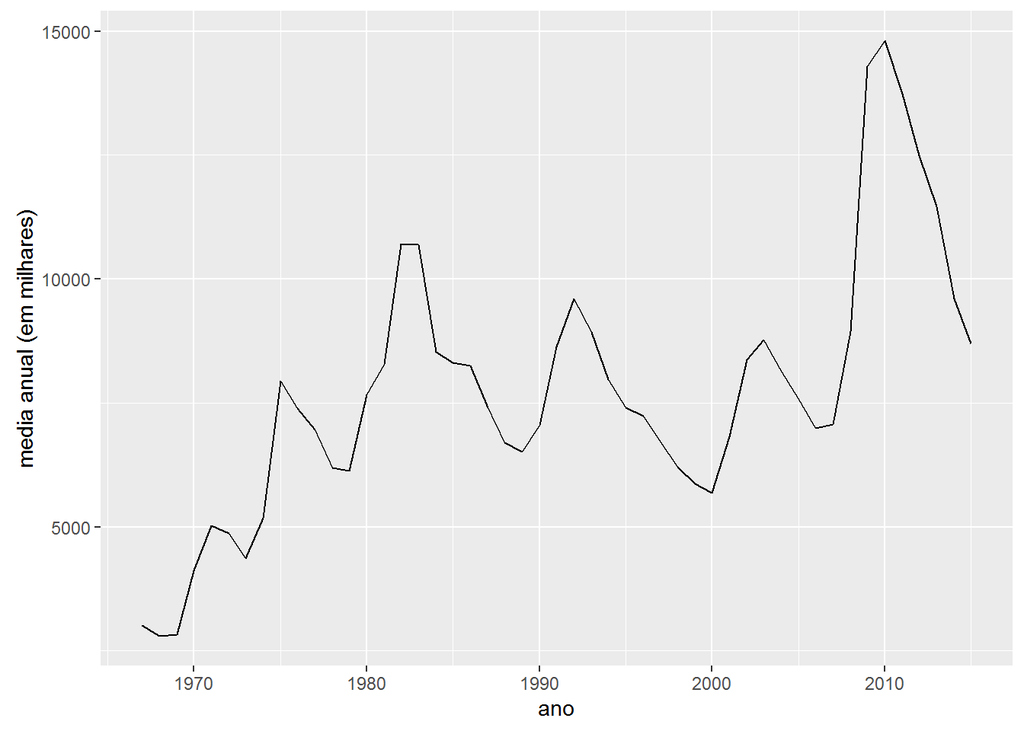

```r
eco2 <- eco1 %>%
  group_by(ano) %>%
  summarise(media_ano = mean(unemploy))
eco2 %>%
  ggplot(aes(x = as.numeric(ano), y = media_ano))+
  xlab("ano")+
  ylab("media anual (em milhares)")+
  geom_line()
```

Tente reproduzir o seguinte grafico: -a linha e a mediana de desempregados por ano -o limite inferior da banda e o quantil de 1% do numero de desempregados -o limite superior da banda e o quantil de 99% do número de desempregados

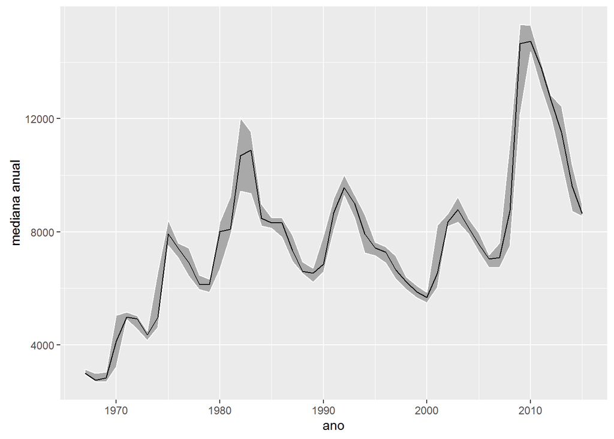

```r
eco3 <- eco1 %>%
  group_by(ano) %>%
  summarise(mediana = median(unemploy),
            quartil1 = quantile(unemploy, probs=0.01),
            quartil99 = quantile(unemploy, probs=0.99))

eco3 %>%
  ggplot(aes(x = as.numeric(ano), y = mediana))+
  xlab("ano")+
  ylab("mediana anual")+
  geom_ribbon(aes(ymin = quartil1, ymax = quartil99), fill = "dark gray", colour = "white")+
  geom_line()
```

Comparar a evolucao no tempo dos indices pce, psaver e taxa de desemprego (unemploy/pop).

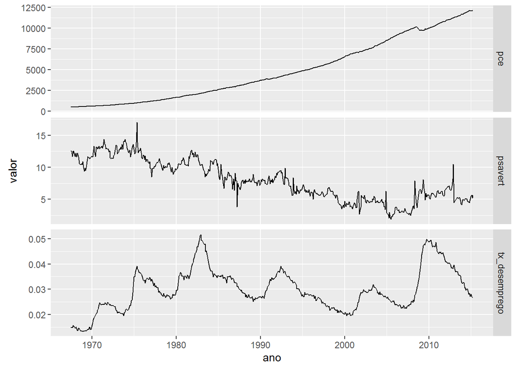

```r
eco4 <- economics %>%
  mutate(tx_desemprego = unemploy/pop) %>%
  gather(taxas, valor, tx_desemprego, pce, psavert)

eco4 %>%
  ggplot(aes(x = date, y = valor))+
  xlab("ano")+
  ylab("valor")+
  geom_line()+
  facet_grid(taxas~., scales = "free_y", )
```